# Tree Based Methods

Author

Termeh Shafie

# 1 Review

## 1.1 Models

|  | **Decision Tree** | **Random Forest** | **Gradient Boosting Tree** |
| --- | --- | --- | --- |
| *num trees* | one | many | many |
| *make predictions* | mode or mean of leaf node | each tree votes | sum of tree outputs |
| *tree independence* | NOT applicable | independent | dependent |
| *Data Used* | all | bagging + random feature selection | all |

## 1.2 Decision Trees, Graphically

Let’s load the [penguin data set](https://github.com/allisonhorst/palmerpenguins), and plot the bill length and bill depth for our three species:

```r
# Load libraries
library(readr)
library(ggplot2)

# Read the data
pengwing <- read_csv("09-data/penguins.csv")

# View first few rows (equivalent to .head())
head(pengwing)
```

```
# A tibble: 6 × 9
   ...1 species island    bill_length_mm bill_depth_mm flipper_length_mm
  <dbl> <chr>   <chr>              <dbl>         <dbl>             <dbl>
1     0 Adelie  Torgersen           39.1          18.7               181
2     1 Adelie  Torgersen           39.5          17.4               186
3     2 Adelie  Torgersen           40.3          18                 195
4     3 Adelie  Torgersen           NA            NA                  NA
5     4 Adelie  Torgersen           36.7          19.3               193
6     5 Adelie  Torgersen           39.3          20.6               190
# ℹ 3 more variables: body_mass_g <dbl>, sex <chr>, year <dbl>
```

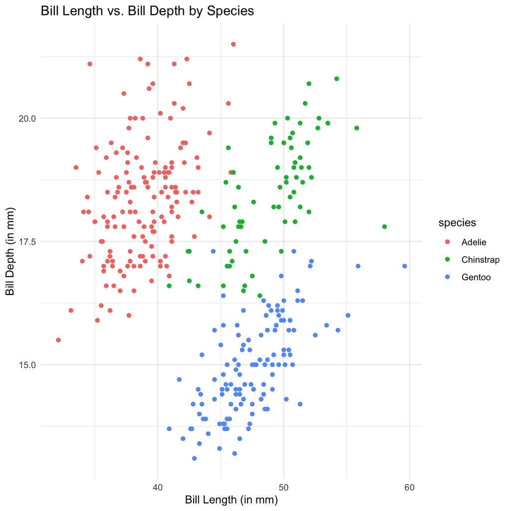

```r
# Create the plot
ggplot(pengwing, aes(x = bill_length_mm, y = bill_depth_mm, color = species)) +
  geom_point() +
  theme_minimal() +
  labs(
    x = "Bill Length (in mm)",
    y = "Bill Depth (in mm)",
    title = "Bill Length vs. Bill Depth by Species"
  )
```

We could use a decision tree based on bill length and bill depth to classify penguins as different species. First, we could split on Bill Depth and decide that any penguin with a depth less than 16.5 mm, should be classified as a Gentoo penguin.

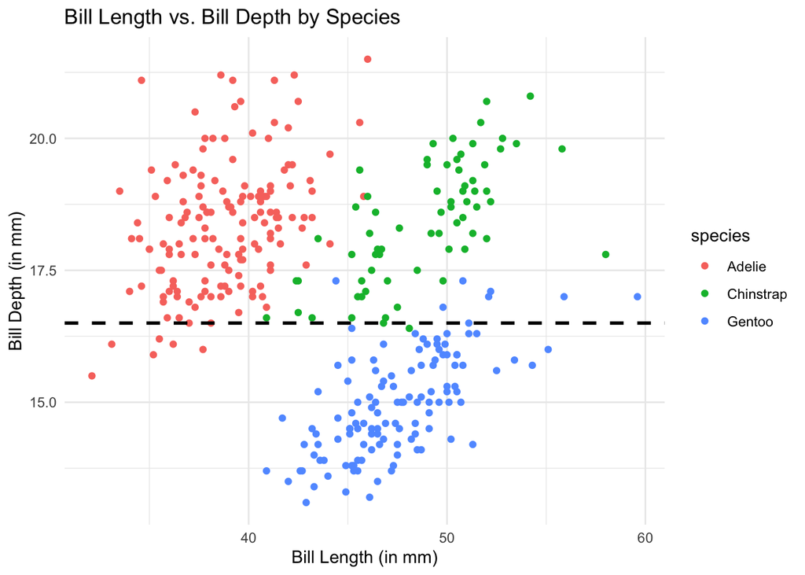

```r
# Choose a split value
split1 <- 16.5

ggplot(pengwing, aes(x = bill_length_mm, y = bill_depth_mm, color = species)) +
  geom_point() +
  theme_minimal() +
  labs(
    x = "Bill Length (in mm)",
    y = "Bill Depth (in mm)",
    title = "Bill Length vs. Bill Depth by Species"
  ) +
  geom_hline(yintercept = split1, linewidth = 1, linetype = "dashed")
```

That bottom group looks GREAT. Now let’s look at the top group. Most of the Chinstrap penguins have longer bill lengths. Let’s say that if a penguin has a bill depth > 16.5mm, then we will split on bill length at 44 to separate the Adelie and Chinstrap penguins.

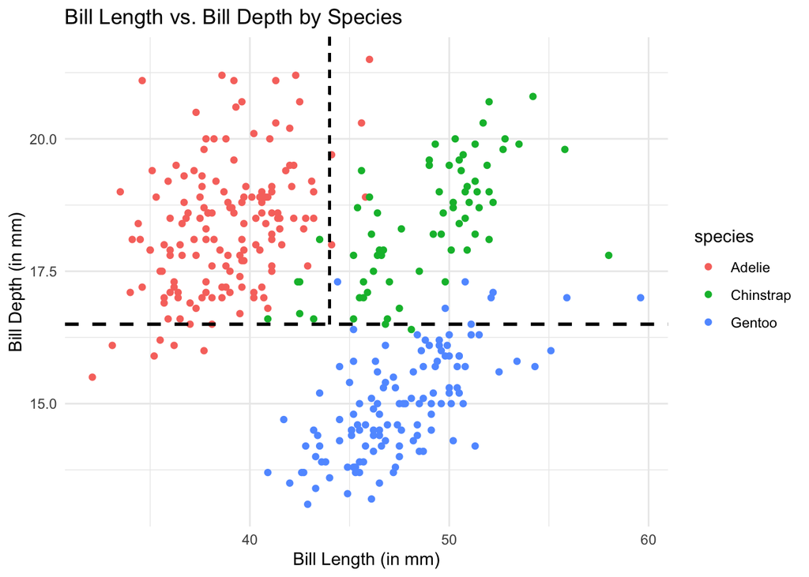

```r
# Choose a split value
split2 <- 44

ggplot(pengwing, aes(x = bill_length_mm, y = bill_depth_mm, color = species)) +
  geom_point() +
  theme_minimal() +
  labs(
    x = "Bill Length (in mm)",
    y = "Bill Depth (in mm)",
    title = "Bill Length vs. Bill Depth by Species"
  ) +
  geom_hline(yintercept = split1, linewidth = 1, linetype = "dashed") +
  geom_segment(
    x = split2, xend = split2,
    y = split1, yend = 22,
    linewidth = 0.6, linetype = "dashed", color = "black"
  )
```

Voila! We’ve built a (very short) decision tree! It would look like this:

```r
# Install if needed
# install.packages("DiagrammeR")

library(DiagrammeR)

grViz("
digraph penguin_tree {

  graph [layout = dot, rankdir = TB]

  node [
    shape = box,
    style = rounded,
    fontname = Helvetica,
    fontsize = 14
  ]

  # Decision nodes
  node1 [label = 'bill_depth < 16.5']
  node2 [label = 'bill_length < 44']

  # Leaf nodes
  gentoo    [label = 'Gentoo', fillcolor = '#dbe9f6', style = 'rounded,filled']
  chinstrap[label = 'Chinstrap', fillcolor = '#e3f0dd', style = 'rounded,filled']
  adelie   [label = 'Adelie', fillcolor = '#f4d6d6', style = 'rounded,filled']

  # Edges
  node1 -> gentoo     [label = 'yes']
  node1 -> node2      [label = 'no']

  node2 -> adelie     [label = 'yes']
  node2 -> chinstrap  [label = 'no']
}
")
```

[interactive chart not shown]

## 1.3 Entropy

Entropy is a measure of disorder/chaos. We want ordered and organized data in the leaf nodes of our decision trees. So we want LOW entropy. **Entropy** is defined as:

$$E = -\sum_1^N p_i* log_2(p_i)$$

Where $N$ is the number of categories or labels in our outcome variable.

This is compared to **gini impurity** which is:

$$GI = 1 - \sum_1^N p_i^2$$

### 1.3.1 Question

WHY do we want the leaf nodes of our tree to be ordered (have low entropy or impurity?)?

## 1.4 Measures of Chaos for a Split

When you split a node, we now have two new nodes. In order to calculate the chaos (entropy or gini impurity) of the split, we have to calculate the chaos (entropy or gini impurity) for EACH of the new nodes and then calculate the weighted average chaos (entropy or gini impurity).

The reason we weight each node differently in this calculation, is because if a node has more data in it, than it has more impact, and therefore its measure of chaos (entropy or gini impurity) should count more.

In general, once you’ve calculated the chaos (entropy or gini impurity) for each of the new nodes, you’ll use this formula to calculate the weighted average:

$$WC = (\frac{N_L}{Total}* C_L) + (\frac{N_R}{Total}* C_R)$$

Where $N_L$ is the number of data points in the Left Node, $N_R$ is the number of data points in the Right Node, and $Total$ is the total number of data points in that split. $C_R$ and $C_L$ are the chaos measure (entropy of gini impurity) for the right and left nodes, respectively.

## 1.5 Decision Trees

Let’s first build a Decision Tree to **classify** patients as diabetic or not diabetic.

Gini impurity is probability of misclassifying a random data point from that node.

```r
# Packages
library(readr)
library(caret)
library(rpart)

# Read data + peek
d <- read_csv("09-data/diabetes2.csv")
head(d)
```

```
# A tibble: 6 × 9
  Pregnancies Glucose BloodPressure SkinThickness Insulin   BMI
        <dbl>   <dbl>         <dbl>         <dbl>   <dbl> <dbl>
1           6     148            72            35       0  33.6
2           1      85            66            29       0  26.6
3           8     183            64             0       0  23.3
4           1      89            66            23      94  28.1
5           0     137            40            35     168  43.1
6           5     116            74             0       0  25.6
# ℹ 3 more variables: DiabetesPedigreeFunction <dbl>, Age <dbl>, Outcome <dbl>
```

```r
# Predictors / outcome
predictors <- c("Pregnancies","Glucose","BloodPressure","SkinThickness",
                "Insulin","BMI","DiabetesPedigreeFunction","Age")

X <- d[, predictors]
y <- d$Outcome   # should be 0/1

# Train/test split (80/20), like random_state=1234
set.seed(1234)
idx_train <- createDataPartition(y, p = 0.8, list = FALSE)
X_train <- X[idx_train, , drop = FALSE]
X_test  <- X[-idx_train, , drop = FALSE]
y_train <- y[idx_train]
y_test  <- y[-idx_train]

# Standardize using TRAIN stats only, then apply to both
pp <- preProcess(X_train, method = c("center", "scale"))
X_train_sc <- predict(pp, X_train)
X_test_sc  <- predict(pp, X_test)

# Fit decision tree (classification)
train_df <- data.frame(X_train_sc, Outcome = factor(y_train))
test_df  <- data.frame(X_test_sc,  Outcome = factor(y_test))

set.seed(1234)
tree <- rpart(Outcome ~ ., data = train_df, method = "class")

# Predict classes
pred_test  <- predict(tree, newdata = test_df, type = "class")
pred_train <- predict(tree, newdata = train_df, type = "class")

# Confusion matrices (test + train), like ConfusionMatrixDisplay
confusionMatrix(pred_test,  test_df$Outcome)
```

```
Confusion Matrix and Statistics

          Reference
Prediction  0  1
         0 76 26
         1 15 36

               Accuracy : 0.732
                 95% CI : (0.6545, 0.8003)
    No Information Rate : 0.5948
    P-Value [Acc > NIR] : 0.0002754

                  Kappa : 0.4279

 Mcnemar's Test P-Value : 0.1183498

            Sensitivity : 0.8352
            Specificity : 0.5806
         Pos Pred Value : 0.7451
         Neg Pred Value : 0.7059
             Prevalence : 0.5948
         Detection Rate : 0.4967
   Detection Prevalence : 0.6667
      Balanced Accuracy : 0.7079

       'Positive' Class : 0
```

```r
confusionMatrix(pred_train, train_df$Outcome)
```

```
Confusion Matrix and Statistics

          Reference
Prediction   0   1
         0 368  60
         1  41 146

               Accuracy : 0.8358
                 95% CI : (0.8041, 0.8642)
    No Information Rate : 0.665
    P-Value [Acc > NIR] : < 2e-16

                  Kappa : 0.6227

 Mcnemar's Test P-Value : 0.07328

            Sensitivity : 0.8998
            Specificity : 0.7087
         Pos Pred Value : 0.8598
         Neg Pred Value : 0.7807
             Prevalence : 0.6650
         Detection Rate : 0.5984
   Detection Prevalence : 0.6959
      Balanced Accuracy : 0.8042

       'Positive' Class : 0
```

### 1.5.1 Limiting Max_Depth

We talked about different ways to “prune” or limit the depth of a tree, both directly and indirectly via `max_depth` and `min_samples_leaf`. Run the following code, what does it tell you:

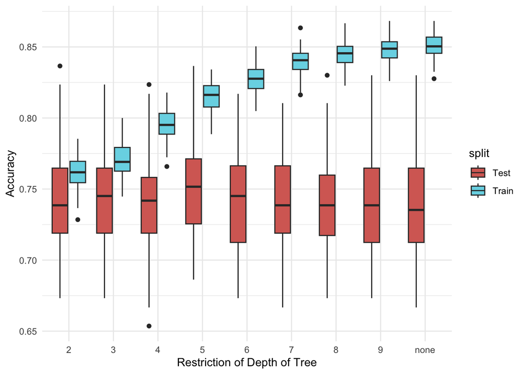

```r
# Function to run repeated train/test evaluation for a given maxdepth
eval_depth <- function(data, depth = NULL, reps = 50, test_prop = 0.2, seed = 1234) {
  set.seed(seed)
  n <- nrow(data)

  out <- data.frame(rep = integer(0), split = character(0), acc = numeric(0))

  for (r in 1:reps) {
    idx_test <- sample.int(n, size = floor(test_prop * n))
    train_df <- data[-idx_test, c(predictors, "Outcome")]
    test_df  <- data[idx_test,  c(predictors, "Outcome")]

    ctrl <- rpart.control(cp = 0, xval = 0)
    if (!is.null(depth)) ctrl$maxdepth <- depth

    fit <- rpart(Outcome ~ ., data = train_df, method = "class", control = ctrl)

    pred_train <- predict(fit, newdata = train_df, type = "class")
    pred_test  <- predict(fit, newdata = test_df,  type = "class")

    acc_train <- mean(pred_train == train_df$Outcome)
    acc_test  <- mean(pred_test  == test_df$Outcome)

    out <- rbind(out,
                 data.frame(rep = r, split = "Test",  acc = acc_test),
                 data.frame(rep = r, split = "Train", acc = acc_train))
  }
  out
}

# Run across depths 2-9 and "none"
depths <- 2:9
all_res <- data.frame()

for (dep in depths) {
  tmp <- eval_depth(d, depth = dep, reps = 60, test_prop = 0.2, seed = 1234)
  tmp$depth <- as.character(dep)
  all_res <- rbind(all_res, tmp)
}

# "none" = no maxdepth cap (use rpart default maxdepth)
tmp_none <- eval_depth(d, depth = NULL, reps = 60, test_prop = 0.2, seed = 1234)
tmp_none$depth <- "none"
all_res <- rbind(all_res, tmp_none)

all_res$depth <- factor(all_res$depth, levels = c(as.character(2:9), "none"))
all_res$split <- factor(all_res$split, levels = c("Test", "Train"))

# Plot
ggplot(all_res, aes(x = depth, y = acc, fill = split)) +
  geom_boxplot(width = 0.7, position = position_dodge(width = 0.8)) +
  scale_fill_manual(values = c("Test" = "#D76B63", "Train" = "#78D7E6")) +
  labs(
    x = "Restriction of Depth of Tree",
    y = "Accuracy"
  ) +
  theme_minimal()
```

### 1.5.2 Random Forests and Gradient Boosting Trees

Now let’s copy and paste the code from above and build a **Random Forest** to predict diabetes instead of a single tree, and then using a **Gradient Boosting Tree**.

```r
library(randomForest)


# Predictors and outcome
predictors <- c(
  "Pregnancies","Glucose","BloodPressure","SkinThickness",
  "Insulin","BMI","DiabetesPedigreeFunction","Age"
)

X <- d[, predictors]
y <- d$Outcome

# Train/test split (80/20)
set.seed(1234)
train_idx <- createDataPartition(y, p = 0.8, list = FALSE)

X_train <- X[train_idx, , drop = FALSE]
X_test  <- X[-train_idx, , drop = FALSE]
y_train <- y[train_idx]
y_test  <- y[-train_idx]

# Standardize predictors (z-score using TRAIN stats)
pp <- preProcess(X_train, method = c("center", "scale"))
X_train_sc <- predict(pp, X_train)
X_test_sc  <- predict(pp, X_test)
# z scoring not important, because none of the variables are influencing/compared to each other directly scale doesn't matter here. But z scoring wont hurt.


# Combine into data frames for modeling
train_df <- data.frame(X_train_sc, Outcome = factor(y_train))
test_df  <- data.frame(X_test_sc,  Outcome = factor(y_test))

# Fit Random Forest
set.seed(1234)
rf_model <- randomForest(
  Outcome ~ .,
  data = train_df,
  ntree = 500,        # number of trees
  mtry = 3,           # variables tried at each split (default ~ sqrt(p))
  importance = TRUE
)

# Predictions
pred_train <- predict(rf_model, train_df)
pred_test  <- predict(rf_model, test_df)

# Confusion matrices
confusionMatrix(pred_train, train_df$Outcome)
```

```
Confusion Matrix and Statistics

          Reference
Prediction   0   1
         0 409   0
         1   0 206

               Accuracy : 1
                 95% CI : (0.994, 1)
    No Information Rate : 0.665
    P-Value [Acc > NIR] : < 2.2e-16

                  Kappa : 1

 Mcnemar's Test P-Value : NA

            Sensitivity : 1.000
            Specificity : 1.000
         Pos Pred Value : 1.000
         Neg Pred Value : 1.000
             Prevalence : 0.665
         Detection Rate : 0.665
   Detection Prevalence : 0.665
      Balanced Accuracy : 1.000

       'Positive' Class : 0
```

```r
confusionMatrix(pred_test,  test_df$Outcome)
```

```
Confusion Matrix and Statistics

          Reference
Prediction  0  1
         0 77 29
         1 14 33

               Accuracy : 0.719
                 95% CI : (0.6407, 0.7886)
    No Information Rate : 0.5948
    P-Value [Acc > NIR] : 0.0009444

                  Kappa : 0.3936

 Mcnemar's Test P-Value : 0.0327626

            Sensitivity : 0.8462
            Specificity : 0.5323
         Pos Pred Value : 0.7264
         Neg Pred Value : 0.7021
             Prevalence : 0.5948
         Detection Rate : 0.5033
   Detection Prevalence : 0.6928
      Balanced Accuracy : 0.6892

       'Positive' Class : 0
```

```r
library(gbm)

# Predictors and outcome
predictors <- c(
  "Pregnancies","Glucose","BloodPressure","SkinThickness",
  "Insulin","BMI","DiabetesPedigreeFunction","Age"
)

X <- d[, predictors]
y <- d$Outcome # must be numeric 0/1 and not factor as earlier


# Train/test split (80/20)
set.seed(1234)
train_idx <- createDataPartition(y, p = 0.8, list = FALSE)

X_train <- X[train_idx, , drop = FALSE]
X_test  <- X[-train_idx, , drop = FALSE]
y_train <- y[train_idx]
y_test  <- y[-train_idx]

# Standardize predictors (z-score using TRAIN stats)
pp <- preProcess(X_train, method = c("center", "scale"))
X_train_sc <- predict(pp, X_train)
X_test_sc  <- predict(pp, X_test)
# z scoring not important, because none of the variables are influencing/compared to each other directly scale doesn't matter here. But z scoring wont hurt.


# Combine into data frames for modeling
train_df <- data.frame(X_train_sc, Outcome = y_train)
test_df  <- data.frame(X_test_sc,  Outcome = y_test)

# Fit Gradient Boosting model
set.seed(1234)
gb_model <- gbm(
  Outcome ~ .,
  data = train_df,
  distribution = "bernoulli",   # binary classification
  n.trees = 300,
  interaction.depth = 3,        # tree depth
  shrinkage = 0.05,              # learning rate
  n.minobsinnode = 10,
  bag.fraction = 0.8,
  verbose = FALSE
)

# Predict probabilities
prob_train <- predict(gb_model, train_df, n.trees = 300, type = "response")
prob_test  <- predict(gb_model, test_df,  n.trees = 300, type = "response")

# Convert probabilities to class labels (0.5 threshold)
pred_train <- factor(ifelse(prob_train > 0.5, 1, 0))
pred_test  <- factor(ifelse(prob_test  > 0.5, 1, 0))

# Convert truth to factor with matching levels
train_truth <- factor(train_df$Outcome, levels = c(0, 1))
test_truth  <- factor(test_df$Outcome,  levels = c(0, 1))

pred_train <- factor(pred_train, levels = c(0, 1))
pred_test  <- factor(pred_test,  levels = c(0, 1))

# Confusion matrices
confusionMatrix(pred_train, train_truth)
```

```
Confusion Matrix and Statistics

          Reference
Prediction   0   1
         0 392  43
         1  17 163

               Accuracy : 0.9024
                 95% CI : (0.8762, 0.9247)
    No Information Rate : 0.665
    P-Value [Acc > NIR] : < 2.2e-16

                  Kappa : 0.7739

 Mcnemar's Test P-Value : 0.001249

            Sensitivity : 0.9584
            Specificity : 0.7913
         Pos Pred Value : 0.9011
         Neg Pred Value : 0.9056
             Prevalence : 0.6650
         Detection Rate : 0.6374
   Detection Prevalence : 0.7073
      Balanced Accuracy : 0.8748

       'Positive' Class : 0
```

```r
confusionMatrix(pred_test,  test_truth)
```

```
Confusion Matrix and Statistics

          Reference
Prediction  0  1
         0 78 29
         1 13 33

               Accuracy : 0.7255
                 95% CI : (0.6476, 0.7945)
    No Information Rate : 0.5948
    P-Value [Acc > NIR] : 0.0005179

                  Kappa : 0.4061

 Mcnemar's Test P-Value : 0.0206376

            Sensitivity : 0.8571
            Specificity : 0.5323
         Pos Pred Value : 0.7290
         Neg Pred Value : 0.7174
             Prevalence : 0.5948
         Detection Rate : 0.5098
   Detection Prevalence : 0.6993
      Balanced Accuracy : 0.6947

       'Positive' Class : 0
```

### 1.5.3 Using Trees for Regression

Lastly, let’s take a quick look at what we’d need to change if we wanted to predict a *continuous* value instead of a categorical one. Let’s look at this data set that measures risk propensity. We’re going to predict BART Scores (a score where higher values mean you’re riskier), based on a bunch of different measures.

These are the variables in the data set:

BART: Balloon Analogue Risk Task - Measures risk-taking behavior - Higher scores means more willingness to take risks - This is the outcome (target variable)

BIS/BAS: Behavioral Inhibition / Behavioral Activation Scales - BISmeans sensitivity to punishment / avoidance - BAS means sensitivity to reward / approach behavior

Female - Binary variable (0/1)

Goal of the model is to use psychological traits (BIS/BAS + gender) to predict risk-taking behavior (BART score) using linear regression, evaluated with 5-fold cross-validation.

```r
# read and clean data----
bart <- read_csv(
  "09-data/bart.csv"
)
# Drop missing values
bart <- na.omit(bart)

# Reset row names
rownames(bart) <- NULL

# Define predictors and outcome----
# Outcome
y <- bart$BART

# Predictors
predictors <- setdiff(colnames(bart), "BART")

# Continuous predictors (everything except Female)
contin <- setdiff(predictors, "Female")

X <- bart[, predictors]

# set up CV with 5 folds-----
set.seed(1234)
kf <- createFolds(y, k = 5, returnTrain = TRUE)

# Storage for metrics ----
mse  <- list(train = c(), test = c())
mae  <- list(train = c(), test = c())
mape <- list(train = c(), test = c())
r2   <- list(train = c(), test = c())


# Cross-validation loop
for (i in seq_along(kf)) {

  train_idx <- kf[[i]]
  test_idx  <- setdiff(seq_len(nrow(X)), train_idx)

  X_train <- X[train_idx, ]
  X_test  <- X[test_idx, ]
  y_train <- y[train_idx]
  y_test  <- y[test_idx]

  # Z-score continuous predictors only
  pp <- preProcess(X_train[, contin], method = c("center", "scale"))

  X_train_sc <- X_train
  X_test_sc  <- X_test

  X_train_sc[, contin] <- predict(pp, X_train[, contin])
  X_test_sc[, contin]  <- predict(pp, X_test[, contin])

  # Fit linear regression
  train_df <- data.frame(X_train_sc, BART = y_train)
  test_df  <- data.frame(X_test_sc,  BART = y_test)

  lm_fit <- lm(BART ~ ., data = train_df)

  # Predictions
  pred_train <- predict(lm_fit, train_df)
  pred_test  <- predict(lm_fit, test_df)

  # Metrics
  mse$train  <- c(mse$train, mean((y_train - pred_train)^2))
  mse$test   <- c(mse$test,  mean((y_test  - pred_test)^2))

  mae$train  <- c(mae$train, mean(abs(y_train - pred_train)))
  mae$test   <- c(mae$test,  mean(abs(y_test  - pred_test)))

  mape$train <- c(mape$train, mean(abs((y_train - pred_train) / y_train)))
  mape$test  <- c(mape$test,  mean(abs((y_test  - pred_test)  / y_test)))

  r2$train   <- c(r2$train, cor(y_train, pred_train)^2)
  r2$test    <- c(r2$test,  cor(y_test,  pred_test)^2)
}


# Create summary table-----
results_table <- data.frame(
  Metric = c("MSE", "MAE", "MAPE", "R²"),
  Train = c(
    mean(mse$train),
    mean(mae$train),
    mean(mape$train),
    mean(r2$train)
  ),
  Test = c(
    mean(mse$test),
    mean(mae$test),
    mean(mape$test),
    mean(r2$test)
  )
)

# Print table
results_table
```

```
  Metric        Train         Test
1    MSE 143.01960222 146.17530363
2    MAE  10.49211192  10.59655360
3   MAPE   0.87809521   0.88646195
4     R²   0.06309417   0.05407431
```

We can interpret the results as follows: The linear regression model shows poor predictive performance, explaining only 5–6% of the variance in BART scores. Train and test errors were nearly identical, indicating no overfitting but substantial underfitting. These results suggest that BIS/BAS traits and gender alone are insufficient predictors of risk-taking behavior as measured by the BART.

Next step would be to try non-linear models (Random Forest, Gradient Boosting).

```r
set.seed(1234)
folds <- createFolds(y, k = 5, returnTrain = TRUE)

mse  <- list(train = c(), test = c())
mae  <- list(train = c(), test = c())
mape <- list(train = c(), test = c())
r2   <- list(train = c(), test = c())

for (i in seq_along(folds)) {
  tr <- folds[[i]]
  te <- setdiff(seq_len(nrow(X)), tr)

  X_train <- X[tr, , drop = FALSE]
  X_test  <- X[te, , drop = FALSE]
  y_train <- y[tr]
  y_test  <- y[te]

  # z-score continuous predictors using TRAIN stats
  pp <- preProcess(X_train[, contin, drop = FALSE], method = c("center", "scale"))
  X_train_sc <- X_train; X_test_sc <- X_test
  X_train_sc[, contin] <- predict(pp, X_train[, contin, drop = FALSE])
  X_test_sc[, contin]  <- predict(pp, X_test[, contin, drop = FALSE])

  train_df <- data.frame(X_train_sc, BART = y_train)
  test_df  <- data.frame(X_test_sc,  BART = y_test)

  set.seed(1234)
  rf_fit <- randomForest(
    BART ~ .,
    data = train_df,
    ntree = 500,
    mtry = max(1, floor(sqrt(length(predictors))))
  )

  pred_train <- predict(rf_fit, train_df)
  pred_test  <- predict(rf_fit, test_df)

  mse$train  <- c(mse$train, mean((y_train - pred_train)^2))
  mse$test   <- c(mse$test,  mean((y_test  - pred_test)^2))

  mae$train  <- c(mae$train, mean(abs(y_train - pred_train)))
  mae$test   <- c(mae$test,  mean(abs(y_test  - pred_test)))

  mape$train <- c(mape$train, mean(abs((y_train - pred_train) / y_train)))
  mape$test  <- c(mape$test,  mean(abs((y_test  - pred_test)  / y_test)))

  r2$train   <- c(r2$train, cor(y_train, pred_train)^2)
  r2$test    <- c(r2$test,  cor(y_test,  pred_test)^2)
}

rf_results <- data.frame(
  Model = "Random Forest",
  Metric = c("MSE", "MAE", "MAPE", "R^2"),
  Train = c(mean(mse$train), mean(mae$train), mean(mape$train), mean(r2$train)),
  Test  = c(mean(mse$test),  mean(mae$test),  mean(mape$test),  mean(r2$test))
)

rf_results
```

```
          Model Metric      Train        Test
1 Random Forest    MSE 49.4503557 133.4441967
2 Random Forest    MAE  5.7125156   9.5465513
3 Random Forest   MAPE  0.4700485   0.7912291
4 Random Forest    R^2  0.7497229   0.1468698
```

```r
set.seed(1234)
folds <- createFolds(y, k = 5, returnTrain = TRUE)

mse_g  <- list(train = c(), test = c())
mae_g  <- list(train = c(), test = c())
mape_g <- list(train = c(), test = c())
r2_g   <- list(train = c(), test = c())

for (i in seq_along(folds)) {
  tr <- folds[[i]]
  te <- setdiff(seq_len(nrow(X)), tr)

  X_train <- X[tr, , drop = FALSE]
  X_test  <- X[te, , drop = FALSE]
  y_train <- y[tr]
  y_test  <- y[te]

  # z-score continuous predictors using TRAIN stats
  pp <- preProcess(X_train[, contin, drop = FALSE], method = c("center", "scale"))
  X_train_sc <- X_train; X_test_sc <- X_test
  X_train_sc[, contin] <- predict(pp, X_train[, contin, drop = FALSE])
  X_test_sc[, contin]  <- predict(pp, X_test[, contin, drop = FALSE])

  train_df <- data.frame(X_train_sc, BART = y_train)
  test_df  <- data.frame(X_test_sc,  BART = y_test)

  set.seed(1234)
  gb_fit <- gbm(
    BART ~ .,
    data = train_df,
    distribution = "gaussian",     # regression
    n.trees = 1500,
    interaction.depth = 3,
    shrinkage = 0.01,
    n.minobsinnode = 10,
    bag.fraction = 0.8,
    verbose = FALSE
  )

  pred_train <- predict(gb_fit, train_df, n.trees = 1500)
  pred_test  <- predict(gb_fit, test_df,  n.trees = 1500)

  mse_g$train  <- c(mse_g$train, mean((y_train - pred_train)^2))
  mse_g$test   <- c(mse_g$test,  mean((y_test  - pred_test)^2))

  mae_g$train  <- c(mae_g$train, mean(abs(y_train - pred_train)))
  mae_g$test   <- c(mae_g$test,  mean(abs(y_test  - pred_test)))

  mape_g$train <- c(mape_g$train, mean(abs((y_train - pred_train) / y_train)))
  mape_g$test  <- c(mape_g$test,  mean(abs((y_test  - pred_test)  / y_test)))

  r2_g$train   <- c(r2_g$train, cor(y_train, pred_train)^2)
  r2_g$test    <- c(r2_g$test,  cor(y_test,  pred_test)^2)
}

gb_results <- data.frame(
  Model = "Gradient Boosting",
  Metric = c("MSE", "MAE", "MAPE", "R^2"),
  Train = c(mean(mse_g$train), mean(mae_g$train), mean(mape_g$train), mean(r2_g$train)),
  Test  = c(mean(mse_g$test),  mean(mae_g$test),  mean(mape_g$test),  mean(r2_g$test))
)

gb_results
```

```
              Model Metric       Train        Test
1 Gradient Boosting    MSE 100.5563924 131.6130762
2 Gradient Boosting    MAE   8.2969512   9.5293227
3 Gradient Boosting   MAPE   0.6858956   0.7808945
4 Gradient Boosting    R^2   0.3510419   0.1564954
```

Let’s combine the results to compare:

```r
all_results <- rbind(rf_results, gb_results)
all_results
```

```
              Model Metric       Train        Test
1     Random Forest    MSE  49.4503557 133.4441967
2     Random Forest    MAE   5.7125156   9.5465513
3     Random Forest   MAPE   0.4700485   0.7912291
4     Random Forest    R^2   0.7497229   0.1468698
5 Gradient Boosting    MSE 100.5563924 131.6130762
6 Gradient Boosting    MAE   8.2969512   9.5293227
7 Gradient Boosting   MAPE   0.6858956   0.7808945
8 Gradient Boosting    R^2   0.3510419   0.1564954
```

What do you conclude?

**Interpretation**

While Random Forest achieved excellent training performance, it substantially overfit and failed to generalize. Gradient Boosting produced slightly better test performance and more stable behavior, though overall predictive power remained modest. These results suggest that nonlinear relationships exist but that BIS/BAS measures and gender alone account for only a small portion of variance in BART risk-taking behavior.

### 1.5.4 Feature Importance

```r
# Assuming rf_fit was trained on train_df
rf_imp <- importance(rf_fit)

# Convert to data frame
rf_imp_df <- data.frame(
  Feature = rownames(rf_imp),
  Importance = rf_imp[, "IncNodePurity"]
)

# Sort by importance
rf_imp_df <- rf_imp_df[order(rf_imp_df$Importance, decreasing = TRUE), ]

rf_imp_df
```

```
                                                        Feature Importance
BAS.Drive.Score                                 BAS.Drive.Score  17676.021
BAS.Fun.Seeking.Score                     BAS.Fun.Seeking.Score  16728.337
Age                                                         Age  15398.407
BIS.Score                                             BIS.Score  14628.120
BAS.Reward.Responsiveness.Score BAS.Reward.Responsiveness.Score  14473.869
Female                                                   Female   3253.537
```

```r
# Relative influence from gbm
gb_imp <- summary(gb_fit, plotit = FALSE)

gb_imp
```

```
                                                            var   rel.inf
BAS.Fun.Seeking.Score                     BAS.Fun.Seeking.Score 25.462993
BAS.Drive.Score                                 BAS.Drive.Score 25.375267
BAS.Reward.Responsiveness.Score BAS.Reward.Responsiveness.Score 21.312970
BIS.Score                                             BIS.Score 13.361662
Age                                                         Age 12.722097
Female                                                   Female  1.765011
```

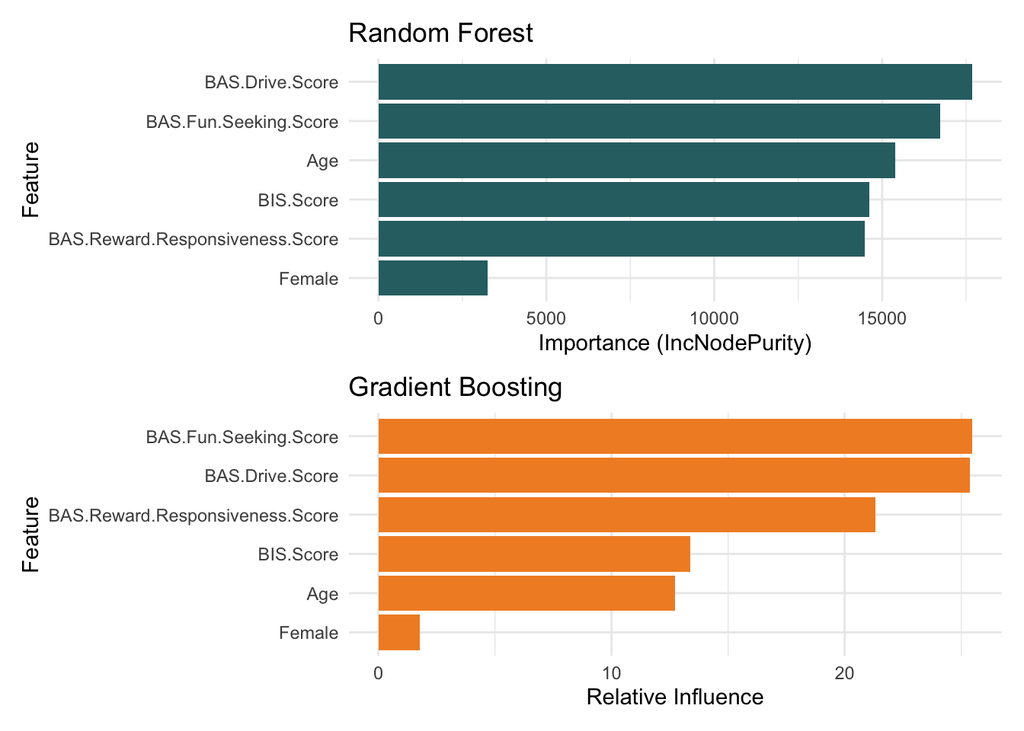

```r
library(patchwork)

# Random Forest plot
p_rf <- ggplot(rf_imp_df, aes(x = reorder(Feature, Importance), y = Importance)) +
  geom_col(fill = "#2F6F73") +
  coord_flip() +
  labs(
    title = "Random Forest",
    x = "Feature",
    y = "Importance (IncNodePurity)"
  ) +
  theme_minimal()

# Gradient Boosting plot
p_gb <- ggplot(gb_imp, aes(x = reorder(var, rel.inf), y = rel.inf)) +
  geom_col(fill = "#F28E2B") +
  coord_flip() +
  labs(
    title = "Gradient Boosting",
    x = "Feature",
    y = "Relative Influence"
  ) +
  theme_minimal()

p_rf / p_gb
```

# 2 Classwork

Using the `bmd.csv`, fit a tree to predict bone mineral density (BMD) based on AGE.

```r
#libraries that we will need
set.seed(1234) #fix the random generator seed

library(rpart)  #library for CART
library(rpart.plot) # plotting
#read the dataset
bmd.data     <-  read.csv(
  "09-data/bmd.csv", stringsAsFactors = TRUE
)
```

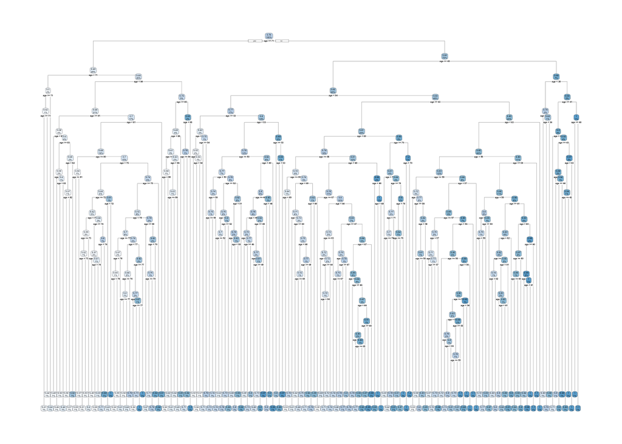

```r
t1 <- rpart(bmd ~ age,
            data = bmd.data,
            method = "anova",         #indicates the outcome is continuous
            control = rpart.control(
                       minsplit = 1,  # min number of observ for a split
                       minbucket = 1, # min nr of obs in terminal nodes
                       cp=0)          #decrease in complex for a split
)

#the rpart.plot() may take a long time to plot
#the complete tree
#if you cannot run it, just try plot(t1); text(t1, pretty=1)
#and you will see just the structure of the tree
rpart.plot(t1)
```

We can now prune the tree using a limit for the complexity parameter CP. This will indicate that only a split with CP higher than the limit is worth it.

```r
printcp(t1)                      #CP for the complete tree
```

```
Regression tree:
rpart(formula = bmd ~ age, data = bmd.data, method = "anova",
    control = rpart.control(minsplit = 1, minbucket = 1, cp = 0))

Variables actually used in tree construction:
[1] age

Root node error: 4.659/169 = 0.027568

n= 169

            CP nsplit  rel error  xerror    xstd
1   1.5011e-01      0 1.0000e+00 1.00752 0.11223
2   2.2857e-02      1 8.4989e-01 0.88021 0.11329
3   2.1625e-02      2 8.2703e-01 1.00527 0.12150
```

[output cut: 111 more lines]

```r
prune.t1 <- prune(t1, cp=0.02)   #prune the tree with cp=0.02

printcp(prune.t1)
```

```
Regression tree:
rpart(formula = bmd ~ age, data = bmd.data, method = "anova",
    control = rpart.control(minsplit = 1, minbucket = 1, cp = 0))

Variables actually used in tree construction:
[1] age

Root node error: 4.659/169 = 0.027568

n= 169

        CP nsplit rel error  xerror    xstd
1 0.150111      0   1.00000 1.00752 0.11223
2 0.022857      1   0.84989 0.88021 0.11329
3 0.021625      2   0.82703 1.00527 0.12150
4 0.020621      8   0.69728 1.02789 0.12227
5 0.020000     11   0.62374 1.02015 0.12170
```

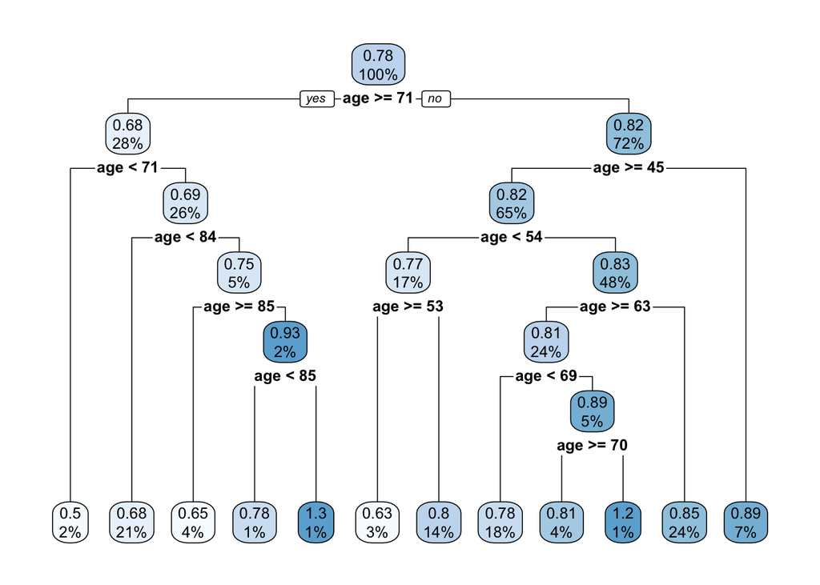

```r
rpart.plot(prune.t1)              #pruned tree
```

The `printcp()` function is used to examine the complexity parameter table and identify an appropriate pruning threshold. The tree is then pruned using cp = 0.02, which removes splits that do not sufficiently reduce prediction error, resulting in a simpler and more generalizable model.

In summary: CP controls tree size, i.e.

- It penalizes adding splits that don’t improve the model enough
- A split is kept only if it reduces error by at least CP

Let’s use the pruned tree from aboved to predict the BMD for an individual 70 years old and compare it with the predictions from a linear model. We plot the predictions from the tree for ages 40 through 90 together with the predictions from the linear model:

```r
lm1 <- lm(bmd ~ age,
           data = bmd.data)

predict(prune.t1,                       #prediction using the tree
        newdata = data.frame(age=70))
```

```
        1
0.8070857
```

```r
predict(lm1,                           #prediction using the linear model
        newdata = data.frame(age=70))
```

```
        1
0.7567922
```

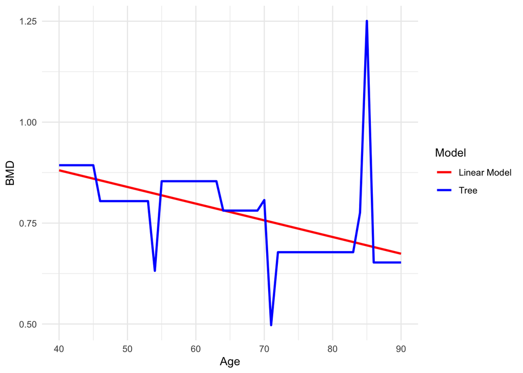

```r
# Create prediction grid
age_grid <- data.frame(age = seq(40, 90, 1))

# Get predictions
age_grid$tree <- predict(prune.t1, newdata = age_grid)
age_grid$linear <- predict(lm1, newdata = age_grid)

# Convert to long format for ggplot
plot_df <- data.frame(
  age = rep(age_grid$age, 2),
  bmd = c(age_grid$tree, age_grid$linear),
  model = factor(
    rep(c("Tree", "Linear Model"), each = nrow(age_grid))
  )
)

# Plot
ggplot(plot_df, aes(x = age, y = bmd, color = model)) +
  geom_line(linewidth = 1) +
  scale_color_manual(
    values = c(
      "Tree" = "blue",
      "Linear Model" = "red"
    )
  ) +
  labs(
    x = "Age",
    y = "BMD",
    color = "Model"
  ) +
  theme_minimal()
```

Let’s fit now a tree to predict bone mineral density (BMD) based on AGE, SEX and BMI (BMI has to be computed) and compute the MSE.

Notice that the caret will prune the tree based on the cross-validated cp.

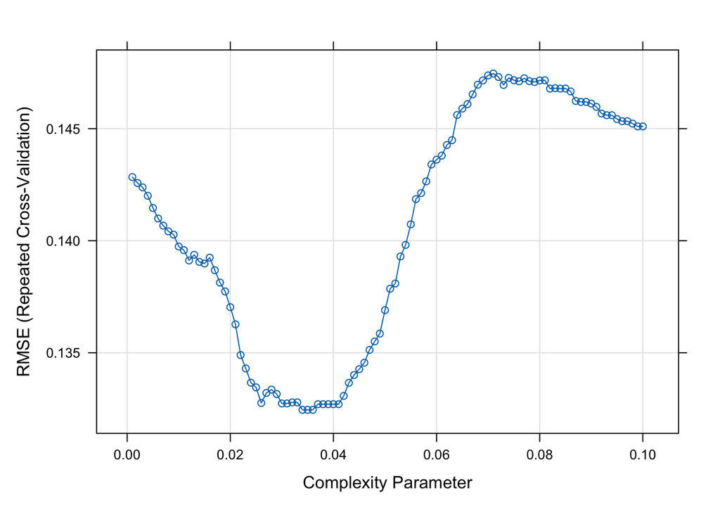

```r
#compute BMI
bmd.data$bmi <- bmd.data$weight_kg / (bmd.data$height_cm/100)^2

trctrl <- trainControl(method = "repeatedcv", number = 10, repeats = 10)
t2.caret  <-  train(bmd ~ age + sex + bmi,
                        data = bmd.data,
                        method = "rpart",
                        trControl=trctrl,
                        tuneGrid = expand.grid(cp=seq(0.001, 0.1, 0.001))
                        )

#Plot the RMSE versus the CP
plot(t2.caret)
```

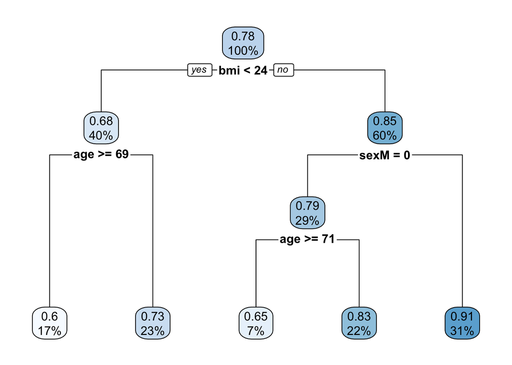

```r
#Plot the tree with the optimal CP
rpart.plot(t2.caret$finalModel)
```

We can compare the RMSE and R2 of the tree above with the linear model:

```r
trctrl <- trainControl(method = "repeatedcv", number = 5, repeats = 10)
lm2.caret<-  train(bmd ~ age + sex + bmi,
                        data = bmd.data,
                        method = "lm",
                        trControl=trctrl
                        )

lm2.caret$results
```

```
  intercept      RMSE  Rsquared       MAE     RMSESD RsquaredSD      MAESD
1      TRUE 0.1374844 0.3307248 0.1041004 0.02212903  0.1310581 0.01472284
```

```r
t2.caret$finalModel$cptable
```

```
          CP nsplit rel error
1 0.26960125      0 1.0000000
2 0.07577601      1 0.7303988
3 0.06448418      2 0.6546227
4 0.05400352      3 0.5901386
5 0.03600000      4 0.5361350
```

```r
#extracts the row with the RMSE and R2 from the table of results
#corresponding to the cp with lowest RMSE  (best tune)
t2.caret$results[t2.caret$results$cp==t2.caret$bestTune[1,1], ]
```

```
      cp      RMSE  Rsquared       MAE     RMSESD RsquaredSD      MAESD
36 0.036 0.1324524 0.3988161 0.1027905 0.02556867  0.1817756 0.01802933
```

Now by yourselves try to fit random forests and gradient boosting trees. Compare the results from these fits, and to the fit ofd the linear model.